# Reproducible Research : Assignment1

=========================================

## Setting global parameters

*Load the data (i.e. read.csv())*

```r
        library("knitr")
        library(plyr)
        opts_chunk$set(echo=TRUE, results="hide")
        setwd("~/Desktop/Coursera")
        dataCSV<-read.csv("activity.csv",sep=',',header=TRUE)
```

## Preprocessing the data

*What is mean total number of steps taken per day?*

- Total number of steps taken per day
- Histogram of the total number of steps taken each day
- Mean and median of the total number of steps taken per day

```r
        StepsDay<-ddply(dataCSV,~date,summarise,nbsteps=sum(steps))
        knitr::kable(StepsDay)
```

| date | nbsteps |
| --- | --- |
| 2012-10-01 | NA |
| 2012-10-02 | 126 |
| 2012-10-03 | 11352 |
| 2012-10-04 | 12116 |
| 2012-10-05 | 13294 |
| 2012-10-06 | 15420 |
| 2012-10-07 | 11015 |
| 2012-10-08 | NA |
| 2012-10-09 | 12811 |
| 2012-10-10 | 9900 |
| 2012-10-11 | 10304 |
| 2012-10-12 | 17382 |
| 2012-10-13 | 12426 |
| 2012-10-14 | 15098 |
| 2012-10-15 | 10139 |
| 2012-10-16 | 15084 |
| 2012-10-17 | 13452 |
| 2012-10-18 | 10056 |
| 2012-10-19 | 11829 |
| 2012-10-20 | 10395 |
| 2012-10-21 | 8821 |
| 2012-10-22 | 13460 |
| 2012-10-23 | 8918 |
| 2012-10-24 | 8355 |
| 2012-10-25 | 2492 |
| 2012-10-26 | 6778 |
| 2012-10-27 | 10119 |
| 2012-10-28 | 11458 |
| 2012-10-29 | 5018 |
| 2012-10-30 | 9819 |
| 2012-10-31 | 15414 |
| 2012-11-01 | NA |
| 2012-11-02 | 10600 |
| 2012-11-03 | 10571 |
| 2012-11-04 | NA |
| 2012-11-05 | 10439 |
| 2012-11-06 | 8334 |
| 2012-11-07 | 12883 |
| 2012-11-08 | 3219 |
| 2012-11-09 | NA |
| 2012-11-10 | NA |
| 2012-11-11 | 12608 |
| 2012-11-12 | 10765 |
| 2012-11-13 | 7336 |
| 2012-11-14 | NA |
| 2012-11-15 | 41 |
| 2012-11-16 | 5441 |
| 2012-11-17 | 14339 |
| 2012-11-18 | 15110 |
| 2012-11-19 | 8841 |
| 2012-11-20 | 4472 |
| 2012-11-21 | 12787 |
| 2012-11-22 | 20427 |
| 2012-11-23 | 21194 |
| 2012-11-24 | 14478 |
| 2012-11-25 | 11834 |
| 2012-11-26 | 11162 |
| 2012-11-27 | 13646 |
| 2012-11-28 | 10183 |
| 2012-11-29 | 7047 |
| 2012-11-30 | NA |

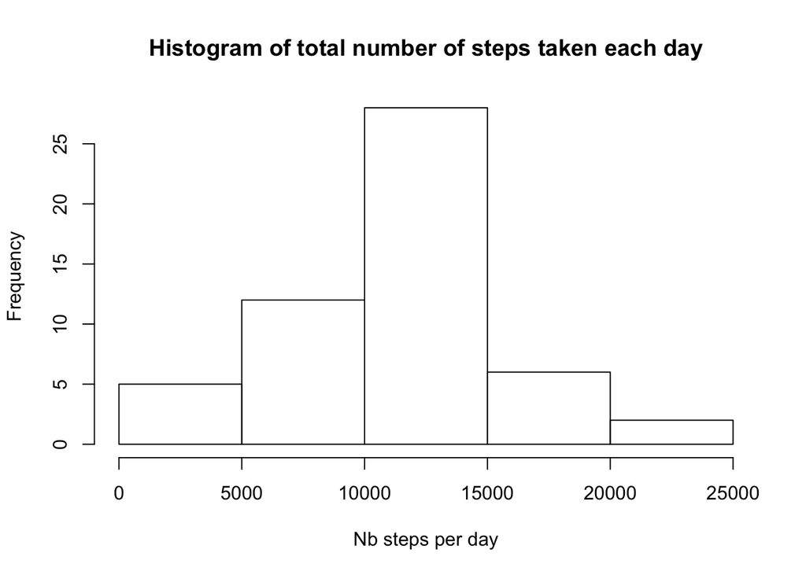

```r
        hist(StepsDay$nbsteps,
             main="Histogram of total number of steps taken each day",
             xlab="Nb steps per day")
```

```r
        StepsDayMean<-ddply(dataCSV,~date,summarise,mean=mean(steps))
        StepsDayMedian<-ddply(dataCSV,~date,summarise,median=median(steps))
        knitr::kable(StepsDayMean)
```

| date | mean |
| --- | --- |
| 2012-10-01 | NA |
| 2012-10-02 | 0.4375000 |
| 2012-10-03 | 39.4166667 |
| 2012-10-04 | 42.0694444 |
| 2012-10-05 | 46.1597222 |
| 2012-10-06 | 53.5416667 |
| 2012-10-07 | 38.2465278 |
| 2012-10-08 | NA |
| 2012-10-09 | 44.4826389 |
| 2012-10-10 | 34.3750000 |
| 2012-10-11 | 35.7777778 |
| 2012-10-12 | 60.3541667 |
| 2012-10-13 | 43.1458333 |
| 2012-10-14 | 52.4236111 |
| 2012-10-15 | 35.2048611 |
| 2012-10-16 | 52.3750000 |
| 2012-10-17 | 46.7083333 |
| 2012-10-18 | 34.9166667 |
| 2012-10-19 | 41.0729167 |
| 2012-10-20 | 36.0937500 |
| 2012-10-21 | 30.6284722 |
| 2012-10-22 | 46.7361111 |
| 2012-10-23 | 30.9652778 |
| 2012-10-24 | 29.0104167 |
| 2012-10-25 | 8.6527778 |
| 2012-10-26 | 23.5347222 |
| 2012-10-27 | 35.1354167 |
| 2012-10-28 | 39.7847222 |
| 2012-10-29 | 17.4236111 |
| 2012-10-30 | 34.0937500 |
| 2012-10-31 | 53.5208333 |
| 2012-11-01 | NA |
| 2012-11-02 | 36.8055556 |
| 2012-11-03 | 36.7048611 |
| 2012-11-04 | NA |
| 2012-11-05 | 36.2465278 |
| 2012-11-06 | 28.9375000 |
| 2012-11-07 | 44.7326389 |
| 2012-11-08 | 11.1770833 |
| 2012-11-09 | NA |
| 2012-11-10 | NA |
| 2012-11-11 | 43.7777778 |
| 2012-11-12 | 37.3784722 |
| 2012-11-13 | 25.4722222 |
| 2012-11-14 | NA |
| 2012-11-15 | 0.1423611 |
| 2012-11-16 | 18.8923611 |
| 2012-11-17 | 49.7881944 |
| 2012-11-18 | 52.4652778 |
| 2012-11-19 | 30.6979167 |
| 2012-11-20 | 15.5277778 |
| 2012-11-21 | 44.3993056 |
| 2012-11-22 | 70.9270833 |
| 2012-11-23 | 73.5902778 |
| 2012-11-24 | 50.2708333 |
| 2012-11-25 | 41.0902778 |
| 2012-11-26 | 38.7569444 |
| 2012-11-27 | 47.3819444 |
| 2012-11-28 | 35.3576389 |
| 2012-11-29 | 24.4687500 |
| 2012-11-30 | NA |

```r
        knitr::kable(StepsDayMedian)
```

| date | median |
| --- | --- |
| 2012-10-01 | NA |
| 2012-10-02 | 0 |
| 2012-10-03 | 0 |
| 2012-10-04 | 0 |
| 2012-10-05 | 0 |
| 2012-10-06 | 0 |
| 2012-10-07 | 0 |
| 2012-10-08 | NA |
| 2012-10-09 | 0 |
| 2012-10-10 | 0 |
| 2012-10-11 | 0 |
| 2012-10-12 | 0 |
| 2012-10-13 | 0 |
| 2012-10-14 | 0 |
| 2012-10-15 | 0 |
| 2012-10-16 | 0 |
| 2012-10-17 | 0 |
| 2012-10-18 | 0 |
| 2012-10-19 | 0 |
| 2012-10-20 | 0 |
| 2012-10-21 | 0 |
| 2012-10-22 | 0 |
| 2012-10-23 | 0 |
| 2012-10-24 | 0 |
| 2012-10-25 | 0 |
| 2012-10-26 | 0 |
| 2012-10-27 | 0 |
| 2012-10-28 | 0 |
| 2012-10-29 | 0 |
| 2012-10-30 | 0 |
| 2012-10-31 | 0 |
| 2012-11-01 | NA |
| 2012-11-02 | 0 |
| 2012-11-03 | 0 |
| 2012-11-04 | NA |
| 2012-11-05 | 0 |
| 2012-11-06 | 0 |
| 2012-11-07 | 0 |
| 2012-11-08 | 0 |
| 2012-11-09 | NA |
| 2012-11-10 | NA |
| 2012-11-11 | 0 |
| 2012-11-12 | 0 |
| 2012-11-13 | 0 |
| 2012-11-14 | NA |
| 2012-11-15 | 0 |
| 2012-11-16 | 0 |
| 2012-11-17 | 0 |
| 2012-11-18 | 0 |
| 2012-11-19 | 0 |
| 2012-11-20 | 0 |
| 2012-11-21 | 0 |
| 2012-11-22 | 0 |
| 2012-11-23 | 0 |
| 2012-11-24 | 0 |
| 2012-11-25 | 0 |
| 2012-11-26 | 0 |
| 2012-11-27 | 0 |
| 2012-11-28 | 0 |
| 2012-11-29 | 0 |
| 2012-11-30 | NA |

*What is the average daily activity pattern?*

- Time series plot (i.e. type = “l”) of the 5-minute interval (x-axis) and the average number of steps taken, averaged across all days (y-axis)

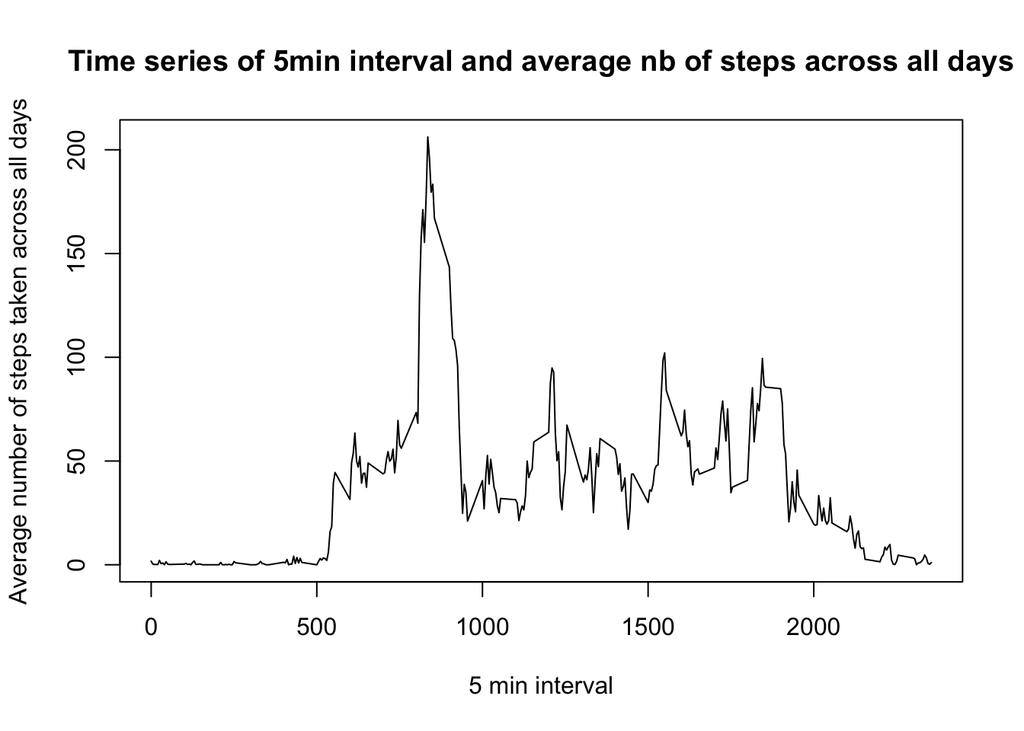

```r
        StepsDayMean<-ddply(dataCSV,~interval,summarise,
             mean=mean(steps,na.rm = TRUE))
        plot(StepsDayMean$interval,StepsDayMean$mean,type="l",
             xlab="5 min interval",ylab="Average number of steps taken across all days",
             main="Time series of 5min interval and average nb of steps across all days")
```

- Which 5-minute interval, on average across all the days in the dataset, contains the maximum number of steps?

```r
        StepsDay<-ddply(dataCSV,~interval,summarise,
             mean=mean(steps,na.rm = TRUE))
        StepsDayMax=max(StepsDay$mean)
        MinInterval<-subset(StepsDay$interval,StepsDay$mean==StepsDayMax)
        knitr::kable(MinInterval)
```

| 835 |
| --- |

*Inputting missing values*

- Total number of missing values in the dataset (i.e. the total number of rows with NAs)

```r
        NbNA<-sum(is.na(dataCSV[,1])==TRUE)
        knitr::kable(NbNA)
```

| 2304 |
| --- |

```r
       opts_chunk$set(echo=TRUE, results="hide")
       dataCSV_2<-dataCSV
       for (i in dataCSV$interval){
            if (is.na(dataCSV$steps==TRUE)){dataCSV_2$steps<-mean(dataCSV$steps,na.rm=T)}
      }
```

- Histogram of the total number of steps taken each day

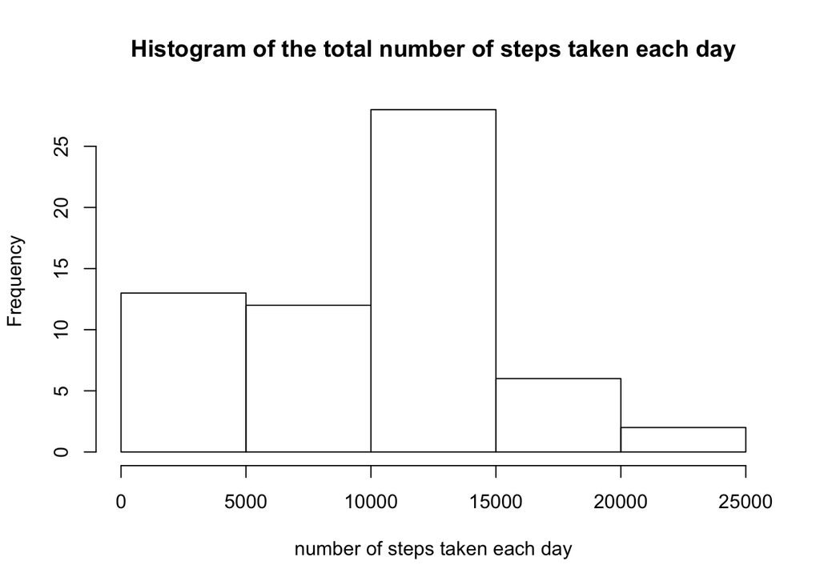

```r
      StepsDay2<-rowsum(dataCSV$steps,dataCSV$date,na.rm=TRUE)
      hist(StepsDay2,main="Histogram of the total number of steps taken each day",
           xlab="number of steps taken each day")
```

- Mean and median total number of steps taken per day.

```r
      StepsDayMean2<-ddply(dataCSV,~date,summarise,
             mean=mean(steps,na.rm = TRUE), median=median(steps,na.rm=TRUE))
      knitr::kable(StepsDayMean2)
```

| date | mean | median |
| --- | --- | --- |
| 2012-10-01 | NaN | NA |
| 2012-10-02 | 0.4375000 | 0 |
| 2012-10-03 | 39.4166667 | 0 |
| 2012-10-04 | 42.0694444 | 0 |
| 2012-10-05 | 46.1597222 | 0 |
| 2012-10-06 | 53.5416667 | 0 |
| 2012-10-07 | 38.2465278 | 0 |
| 2012-10-08 | NaN | NA |
| 2012-10-09 | 44.4826389 | 0 |
| 2012-10-10 | 34.3750000 | 0 |
| 2012-10-11 | 35.7777778 | 0 |
| 2012-10-12 | 60.3541667 | 0 |
| 2012-10-13 | 43.1458333 | 0 |
| 2012-10-14 | 52.4236111 | 0 |
| 2012-10-15 | 35.2048611 | 0 |
| 2012-10-16 | 52.3750000 | 0 |
| 2012-10-17 | 46.7083333 | 0 |
| 2012-10-18 | 34.9166667 | 0 |
| 2012-10-19 | 41.0729167 | 0 |
| 2012-10-20 | 36.0937500 | 0 |
| 2012-10-21 | 30.6284722 | 0 |
| 2012-10-22 | 46.7361111 | 0 |
| 2012-10-23 | 30.9652778 | 0 |
| 2012-10-24 | 29.0104167 | 0 |
| 2012-10-25 | 8.6527778 | 0 |
| 2012-10-26 | 23.5347222 | 0 |
| 2012-10-27 | 35.1354167 | 0 |
| 2012-10-28 | 39.7847222 | 0 |
| 2012-10-29 | 17.4236111 | 0 |
| 2012-10-30 | 34.0937500 | 0 |
| 2012-10-31 | 53.5208333 | 0 |
| 2012-11-01 | NaN | NA |
| 2012-11-02 | 36.8055556 | 0 |
| 2012-11-03 | 36.7048611 | 0 |
| 2012-11-04 | NaN | NA |
| 2012-11-05 | 36.2465278 | 0 |
| 2012-11-06 | 28.9375000 | 0 |
| 2012-11-07 | 44.7326389 | 0 |
| 2012-11-08 | 11.1770833 | 0 |
| 2012-11-09 | NaN | NA |
| 2012-11-10 | NaN | NA |
| 2012-11-11 | 43.7777778 | 0 |
| 2012-11-12 | 37.3784722 | 0 |
| 2012-11-13 | 25.4722222 | 0 |
| 2012-11-14 | NaN | NA |
| 2012-11-15 | 0.1423611 | 0 |
| 2012-11-16 | 18.8923611 | 0 |
| 2012-11-17 | 49.7881944 | 0 |
| 2012-11-18 | 52.4652778 | 0 |
| 2012-11-19 | 30.6979167 | 0 |
| 2012-11-20 | 15.5277778 | 0 |
| 2012-11-21 | 44.3993056 | 0 |
| 2012-11-22 | 70.9270833 | 0 |
| 2012-11-23 | 73.5902778 | 0 |
| 2012-11-24 | 50.2708333 | 0 |
| 2012-11-25 | 41.0902778 | 0 |
| 2012-11-26 | 38.7569444 | 0 |
| 2012-11-27 | 47.3819444 | 0 |
| 2012-11-28 | 35.3576389 | 0 |
| 2012-11-29 | 24.4687500 | 0 |
| 2012-11-30 | NaN | NA |

*Are there differences in activity patterns between weekdays and weekends?*

- New factor variable in the dataset with two levels – “weekday” and “weekend” indicating whether a given date is a weekday or weekend day.

```r
        opts_chunk$set(echo=TRUE)
        require(dplyr)
```

```r
        dataCSV$weekdays<-weekdays(as.Date(dataCSV$date))
        map <- data.frame(weekdays=c("Monday","Tuesday","Wednesday","Thursday","Friday","Saturday","Sunday"),
                          daystype=c(rep("weekday",5),rep("weekend",2)))
        map$weekdays<-as.character(map$weekdays)
        dataCSV<-left_join(dataCSV, map, by="weekdays")
```

- Panel plot containing a time series plot (i.e. type = “l”) of the 5-minute interval (x-axis) and the average number of steps taken, averaged across all weekday days or weekend days (y-axis).

[figure not shown]

```r
        StepsWeekEnd<-subset(dataCSV,daystype=="weekend")
        StepsWeekDays<-subset(dataCSV,daystype=="weekday")
        par(mfrow=c(1,2),mar=c(2,5,7,2))
        plot(StepsWeekDays$interval,StepsWeekDays$mean,type="l", xlab="5min interval",
             ylab="mean steps across week days",
             main="Plot Week Days - Average steps")
        plot(StepsWeekEnd$interval,StepsWeekEnd$mean,type="l", xlab="5min interval",
             ylab="mean steps across weekend days",
             main="Plot Week End - Average steps")
```